**Type-two UI:** The Node-Edge Based graph to visualize the power system properties  
`Timeline:` The event for Active power goes into BUS 4042.  
`Voltage profile for all Buses:` Graph One Node Color.  
`Real Power Flow and Direction for all transmission Line and Transformer:` Graph One Edge color diverse and depth.  
`Power System 400kv Backbone:` Graph One Node Size.  
`Reactive power distribution for all transmission Line and Transformer:`Graph two Node Color, Computing the page rank value with the weight get from the edge attribute and return the list of node value.

**For the First Graph:**  
`Node Size:` The size of node represents the standard voltage level. The greater the voltage value, the larger the node size.  
`Node Color:` The color of node represents the voltage changing range.

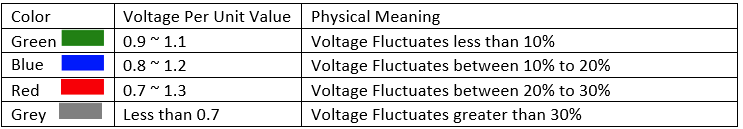

`Graph:` It is a directed graph. The direction of edge illustrates by the direction of arrow.  
`Edge Color:` The color of edge represents the active power. The colormap used here is seismic. It is red when active power is positive. It is blue when active power is negative, which means the active power.

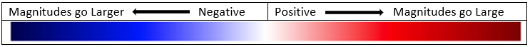

**For the Second Graph:**  
`Graph:` It is a directed graph. The direction of edge illustrates by the direction of arrow.  
`Node Color:` The color of node represents the Page rank value computed by the reactive power. It is yellow when the value is positive. It is gray when the value is negative. The deeper the color, the greater the value.

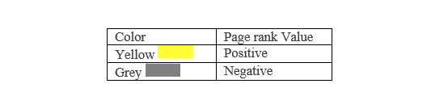